# Documento RMarkdown del Seminario de Fuentes

Daniel De Lara Pérez, Álvaro Velasco García, Gabriel Collado Santamaría

Curso 2022-2023

## Introducción

Con este proyecto, pretendemos averiguar si existe algún tipo de relación estadística entre la muerte *no natural* de niños al nacer y la cantidad de ejercicio físico que llevan a cabo las mujeres embarazadas. Todo ello subcatalogado por Comunidades Autónomas.

Entre los métodos que proponemos para solucionar el problema planteado se encuntran: Uso de pipelines para la concatenación de diferentes funciones, creación de objetos, la utilización de los joins para la combinación de diferentes tablas y encontrar un posible relación entre los dos cojuntos de datos,desarrollo de gráficos para poder visualizar mejor una posible relación entre los datos de interés,etc.

## Objetivos

- Recoger datos porcentuales acerca del número de muertes de niños con menos de una semana de vida por comunidad autónoma y su proporción con el número de niños nacidos en un año.
- Recoger datos sobre la cantidad de deporte practicado por comunidad autónoma entre mujeres en edad fértil y tasarla en tres niveles porcentuales `alto` `moderado` `bajo`
- Estudiar si existe algún tipo de relación entre estos dos grupos.

## Materiales

Los datos utilizados en este estudio son:

- Defunciones de menores de una semana por causas (lista perinatal reducida), sexo y comunidad y ciudad autónoma de residencia del año 2021 - *Gobierno de España*

```r
library(readr)
Muerte_niños_semana <- read_delim("Input/data/Muerte_niños_semana.csv",
                                  delim = ";", escape_double = FALSE, trim_ws = TRUE)
Muerte_niños_semana
```

| Causas (lista perinatal reducida) | Sexo | Nacional | Comunidades y Ciudades Autónomas | Total |
| --- | --- | --- | --- | --- |
| 01-93 I-XXII.Todas las causas | Ambos sexos | Total | NA | 413 |
| 01-93 I-XXII.Todas las causas | Ambos sexos | Total | Andalucía | 94 |
| 01-93 I-XXII.Todas las causas | Ambos sexos | Total | Aragón | 7 |
| 01-93 I-XXII.Todas las causas | Ambos sexos | Total | Asturias, Principado de | 7 |
| 01-93 I-XXII.Todas las causas | Ambos sexos | Total | Balears, Illes | 13 |
| 01-93 I-XXII.Todas las causas | Ambos sexos | Total | Canarias | 12 |
| 01-93 I-XXII.Todas las causas | Ambos sexos | Total | Cantabria | 7 |
| 01-93 I-XXII.Todas las causas | Ambos sexos | Total | Castilla y León | 23 |
| 01-93 I-XXII.Todas las causas | Ambos sexos | Total | Castilla-La Mancha | 15 |
| 01-93 I-XXII.Todas las causas | Ambos sexos | Total | Catalu¤a | 75 |

[output cut: 1880 more lines]

- La Encuesta Nacional de Salud del año 2017- *Ministerio de Sanidad*

```r
library(readxl)
Encuesta_nacional_2017 <- read_excel("Input/data/Encuesta_nacional_2017.xlsx",
                                     sheet = "Hoja1")
Encuesta_nacional_2017
```

| MUJERES | ...2 | ...3 | ...4 | ...5 |
| --- | --- | --- | --- | --- |
| TOTAL | 100 | 18.41 | 44.55 | 37.04 |
| ANDALUCÍA | 100 | 13.46 | 40.45 | 46.09 |
| ARAGÓN | 100 | 7.11 | 45.79 | 47.11 |
| ASTURIAS, PRINCIPADO DE | 100 | 12.42 | 54.79 | 32.79 |
| BALEARS, ILLES | 100 | 12.60 | 50.87 | 36.53 |
| CANARIAS | 100 | 18.54 | 27.21 | 54.26 |
| CANTABRIA | 100 | 5.16 | 59.42 | 35.42 |
| CASTILLA Y LEÓN | 100 | 14.85 | 46.85 | 38.30 |
| CASTILLA-LA MANCHA | 100 | 17.83 | 43.76 | 38.40 |
| CATALUÑA | 100 | 13.03 | 36.24 | 50.73 |

[output cut: 10 more lines]

- La natalidad de las Comunidades Autónomas del año 2021 - *Página web de DatosMacro*

Estos se han importado en formato Excel y CSV, para la Encuesta Nacional de Salud y las defunciones de menores de una semana respectivamente, ya que en algún caso éra la única alternativa para su importación. Dentro de la Encuesta Nacional de Salud, se creo un Hoja de Excel que incluía solamente los datos del nivel de ejercicio de mujeres, a causa de la gran cantidad de datos que este archivo Excel presentaba.

En el caso de la Natalidad por comunidades autónomas se ha requerido la aplicación de la función `clipboard`, debido a que la descarga de datos no era accesible en ningún tipo de formato.

## Métodos y Tablas

```r
library(dplyr)
```

Realizamos el filtrado de los datos de niños muertos: Ambos sexos por CCAA

```r
x1 <-
  Muerte_niños_semana %>%
  group_by(`Comunidades y Ciudades Autónomas`, Sexo) %>%
  select(Total) %>%
  summarise(
    suma_total = sum(Total)
  )


x2 <- na.omit(x1)

muertes_CCAA <- filter(x2, Sexo == "Ambos sexos")
```

```r
knitr::kable(
  head(muertes_CCAA[,1:3],19),
)
```

| Comunidades y Ciudades Autónomas | Sexo | suma_total |
| --- | --- | --- |
| Andalucía | Ambos sexos | 277 |
| Aragón | Ambos sexos | 21 |
| Asturias, Principado de | Ambos sexos | 20 |
| Balears, Illes | Ambos sexos | 39 |
| Canarias | Ambos sexos | 33 |
| Cantabria | Ambos sexos | 20 |
| Castilla-La Mancha | Ambos sexos | 44 |
| Castilla y León | Ambos sexos | 68 |
| Catalu¤a | Ambos sexos | 221 |
| Ceuta | Ambos sexos | 3 |
| Comunitat Valenciana | Ambos sexos | 114 |
| Extremadura | Ambos sexos | 9 |
| Galicia | Ambos sexos | 53 |
| Madrid, Comunidad de | Ambos sexos | 172 |
| Melilla | Ambos sexos | 3 |
| Murcia, Región de | Ambos sexos | 50 |
| Navarra, Comunidad Foral de | Ambos sexos | 6 |
| País Vasco | Ambos sexos | 51 |
| Rioja, La | Ambos sexos | 6 |

Ahora hacemos el filtrado de los datos correspondiente al grado de deporte: Mujeres por CCAA y su nivel de act.física

```r
ejercicio_mujeres_comunidad<-
  Encuesta_nacional_2017 %>%
  slice(.data=.,2:20) %>%
  rename(
    tamaño_muestral=...2,nivel_alto=...3,nivel_moderado=...4,nivel_bajo=...5
  )
```

```r
knitr::kable(
  head(ejercicio_mujeres_comunidad[,1:5],19),
)
```

| MUJERES | tamaño_muestral | nivel_alto | nivel_moderado | nivel_bajo |
| --- | --- | --- | --- | --- |
| ANDALUCÍA | 100 | 13.46 | 40.45 | 46.09 |
| ARAGÓN | 100 | 7.11 | 45.79 | 47.11 |
| ASTURIAS, PRINCIPADO DE | 100 | 12.42 | 54.79 | 32.79 |
| BALEARS, ILLES | 100 | 12.60 | 50.87 | 36.53 |
| CANARIAS | 100 | 18.54 | 27.21 | 54.26 |
| CANTABRIA | 100 | 5.16 | 59.42 | 35.42 |
| CASTILLA Y LEÓN | 100 | 14.85 | 46.85 | 38.30 |
| CASTILLA-LA MANCHA | 100 | 17.83 | 43.76 | 38.40 |
| CATALUÑA | 100 | 13.03 | 36.24 | 50.73 |
| COMUNITAT VALENCIANA | 100 | 37.13 | 42.56 | 20.31 |
| EXTREMADURA | 100 | 33.78 | 47.22 | 19.00 |
| GALICIA | 100 | 3.86 | 58.99 | 37.15 |
| MADRID, COMUNIDAD DE | 100 | 28.38 | 56.03 | 15.59 |
| MURCIA, REGIÓN DE | 100 | 5.17 | 27.13 | 67.70 |
| NAVARRA, COMUNIDAD FORAL DE | 100 | 33.20 | 42.83 | 23.97 |
| PAÍS VASCO | 100 | 18.01 | 56.59 | 25.41 |
| RIOJA, LA | 100 | 11.77 | 42.86 | 45.37 |
| CEUTA | 100 | 4.68 | 16.02 | 79.30 |
| MELILLA | 100 | 55.17 | 33.93 | 10.90 |

Vamos a proceder a la unión de ambas tablas:

- Primero vamos a forzar a que ambas bases de datos tengan los datos en el mismo formato, es decir, en este caso uno presenta los characteres en minúsculas y el otro en mayúsculas. Lo corregimos:

```r
muertes_CCAA$`Comunidades y Ciudades Autónomas`<- toupper(muertes_CCAA$`Comunidades y Ciudades Autónomas`)
muertes_CCAA
```

| Comunidades y Ciudades Autónomas | Sexo | suma_total |
| --- | --- | --- |
| ANDALUCÍA | Ambos sexos | 277 |
| ARAGÓN | Ambos sexos | 21 |
| ASTURIAS, PRINCIPADO DE | Ambos sexos | 20 |
| BALEARS, ILLES | Ambos sexos | 39 |
| CANARIAS | Ambos sexos | 33 |
| CANTABRIA | Ambos sexos | 20 |
| CASTILLA-LA MANCHA | Ambos sexos | 44 |
| CASTILLA Y LEÓN | Ambos sexos | 68 |
| CATALU¤A | Ambos sexos | 221 |
| CEUTA | Ambos sexos | 3 |

[output cut: 9 more lines]

- Busco un atributo común a ambos set de datos

```r
attributes(muertes_CCAA)
```

```
## $class
## [1] "grouped_df" "tbl_df"     "tbl"        "data.frame"
##
## $row.names
##  [1]  1  2  3  4  5  6  7  8  9 10 11 12 13 14 15 16 17 18 19
##
## $names
## [1] "Comunidades y Ciudades Autónomas" "Sexo"
## [3] "suma_total"
##
## $groups
## # A tibble: 19 × 2
##    `Comunidades y Ciudades Autónomas`       .rows
##    <chr>                              <list<int>>
##  1 ANDALUCÍA                                  [1]
##  2 ARAGÓN                                     [1]
##  3 ASTURIAS, PRINCIPADO DE                    [1]
##  4 BALEARS, ILLES                             [1]
##  5 CANARIAS                                   [1]
##  6 CANTABRIA                                  [1]
##  7 CASTILLA-LA MANCHA                         [1]
##  8 CASTILLA Y LEÓN                            [1]
##  9 CATALU¤A                                   [1]
## 10 CEUTA                                      [1]
## 11 COMUNITAT VALENCIANA                       [1]
## 12 EXTREMADURA                                [1]
## 13 GALICIA                                    [1]
## 14 MADRID, COMUNIDAD DE                       [1]
## 15 MELILLA                                    [1]
## 16 MURCIA, REGIÓN DE                          [1]
## 17 NAVARRA, COMUNIDAD FORAL DE                [1]
## 18 PAÍS VASCO                                 [1]
## 19 RIOJA, LA                                  [1]
```

```r
attributes(ejercicio_mujeres_comunidad)
```

```
## $class
## [1] "tbl_df"     "tbl"        "data.frame"
##
## $row.names
##  [1]  1  2  3  4  5  6  7  8  9 10 11 12 13 14 15 16 17 18 19
##
## $names
## [1] "MUJERES"         "tamaño_muestral" "nivel_alto"      "nivel_moderado"
## [5] "nivel_bajo"
```

Sí que presentan un atributo común, pero no con el mismo nombre, uno se llama *Comunidades y Ciudades Autónomas* y el otro *Mujeres*. De forma que vamos a cambiar el nombre de *MUJERES* del set de datos ejercicio_mujeres_comunidad por *Comunidades y Ciudades Autónomas* para que coincidan con el de el set de datos muertes_CCAA:

```r
ejercicio_mujeres_comunidad<-
  ejercicio_mujeres_comunidad %>%
  rename( "Comunidades y Ciudades Autónomas" = MUJERES)
ejercicio_mujeres_comunidad
```

| Comunidades y Ciudades Autónomas | tamaño_muestral | nivel_alto | nivel_moderado | nivel_bajo |
| --- | --- | --- | --- | --- |
| ANDALUCÍA | 100 | 13.46 | 40.45 | 46.09 |
| ARAGÓN | 100 | 7.11 | 45.79 | 47.11 |
| ASTURIAS, PRINCIPADO DE | 100 | 12.42 | 54.79 | 32.79 |
| BALEARS, ILLES | 100 | 12.60 | 50.87 | 36.53 |
| CANARIAS | 100 | 18.54 | 27.21 | 54.26 |
| CANTABRIA | 100 | 5.16 | 59.42 | 35.42 |
| CASTILLA Y LEÓN | 100 | 14.85 | 46.85 | 38.30 |
| CASTILLA-LA MANCHA | 100 | 17.83 | 43.76 | 38.40 |
| CATALUÑA | 100 | 13.03 | 36.24 | 50.73 |
| COMUNITAT VALENCIANA | 100 | 37.13 | 42.56 | 20.31 |

[output cut: 9 more lines]

- Comprobamos los levels:

```r
levels(factor(muertes_CCAA$`Comunidades y Ciudades Autónomas`))
```

```
##  [1] "ANDALUCÍA"                   "ARAGÓN"
##  [3] "ASTURIAS, PRINCIPADO DE"     "BALEARS, ILLES"
##  [5] "CANARIAS"                    "CANTABRIA"
##  [7] "CASTILLA-LA MANCHA"          "CASTILLA Y LEÓN"
##  [9] "CATALU¤A"                    "CEUTA"
## [11] "COMUNITAT VALENCIANA"        "EXTREMADURA"
## [13] "GALICIA"                     "MADRID, COMUNIDAD DE"
## [15] "MELILLA"                     "MURCIA, REGIÓN DE"
## [17] "NAVARRA, COMUNIDAD FORAL DE" "PAÍS VASCO"
## [19] "RIOJA, LA"
```

```r
levels(factor(ejercicio_mujeres_comunidad$"Comunidades y Ciudades Autónomas"))
```

```
##  [1] "ANDALUCÍA"                   "ARAGÓN"
##  [3] "ASTURIAS, PRINCIPADO DE"     "BALEARS, ILLES"
##  [5] "CANARIAS"                    "CANTABRIA"
##  [7] "CASTILLA-LA MANCHA"          "CASTILLA Y LEÓN"
##  [9] "CATALUÑA"                    "CEUTA"
## [11] "COMUNITAT VALENCIANA"        "EXTREMADURA"
## [13] "GALICIA"                     "MADRID, COMUNIDAD DE"
## [15] "MELILLA"                     "MURCIA, REGIÓN DE"
## [17] "NAVARRA, COMUNIDAD FORAL DE" "PAÍS VASCO"
## [19] "RIOJA, LA"
```

Observamos que en **Cataluña** la `ñ` está representada por otro caracter en muertes_CCAA. Corregimos eso:

```r
muertes_CCAA$`Comunidades y Ciudades Autónomas`[9]<-"CATALUÑA"
muertes_CCAA
```

| Comunidades y Ciudades Autónomas | Sexo | suma_total |
| --- | --- | --- |
| ANDALUCÍA | Ambos sexos | 277 |
| ARAGÓN | Ambos sexos | 21 |
| ASTURIAS, PRINCIPADO DE | Ambos sexos | 20 |
| BALEARS, ILLES | Ambos sexos | 39 |
| CANARIAS | Ambos sexos | 33 |
| CANTABRIA | Ambos sexos | 20 |
| CASTILLA-LA MANCHA | Ambos sexos | 44 |
| CASTILLA Y LEÓN | Ambos sexos | 68 |
| CATALUÑA | Ambos sexos | 221 |
| CEUTA | Ambos sexos | 3 |

[output cut: 9 more lines]

- Ya podemos hacer un left join para unir ambas tablas sin que nos salga NA. En realidad estaremos haciendo un natural join al no especificar las columnas a unir:

```r
union_tablas<-left_join(x=ejercicio_mujeres_comunidad,y=muertes_CCAA)
```

```r
knitr::kable(
  head(union_tablas[,1:7],19),
  caption = 'Ambas tablas unificadas'
)
```

Ambas tablas unificadas

| Comunidades y Ciudades Autónomas | tamaño_muestral | nivel_alto | nivel_moderado | nivel_bajo | Sexo | suma_total |
| --- | --- | --- | --- | --- | --- | --- |
| ANDALUCÍA | 100 | 13.46 | 40.45 | 46.09 | Ambos sexos | 277 |
| ARAGÓN | 100 | 7.11 | 45.79 | 47.11 | Ambos sexos | 21 |
| ASTURIAS, PRINCIPADO DE | 100 | 12.42 | 54.79 | 32.79 | Ambos sexos | 20 |
| BALEARS, ILLES | 100 | 12.60 | 50.87 | 36.53 | Ambos sexos | 39 |
| CANARIAS | 100 | 18.54 | 27.21 | 54.26 | Ambos sexos | 33 |
| CANTABRIA | 100 | 5.16 | 59.42 | 35.42 | Ambos sexos | 20 |
| CASTILLA Y LEÓN | 100 | 14.85 | 46.85 | 38.30 | Ambos sexos | 68 |
| CASTILLA-LA MANCHA | 100 | 17.83 | 43.76 | 38.40 | Ambos sexos | 44 |
| CATALUÑA | 100 | 13.03 | 36.24 | 50.73 | Ambos sexos | 221 |
| COMUNITAT VALENCIANA | 100 | 37.13 | 42.56 | 20.31 | Ambos sexos | 114 |
| EXTREMADURA | 100 | 33.78 | 47.22 | 19.00 | Ambos sexos | 9 |
| GALICIA | 100 | 3.86 | 58.99 | 37.15 | Ambos sexos | 53 |
| MADRID, COMUNIDAD DE | 100 | 28.38 | 56.03 | 15.59 | Ambos sexos | 172 |
| MURCIA, REGIÓN DE | 100 | 5.17 | 27.13 | 67.70 | Ambos sexos | 50 |
| NAVARRA, COMUNIDAD FORAL DE | 100 | 33.20 | 42.83 | 23.97 | Ambos sexos | 6 |
| PAÍS VASCO | 100 | 18.01 | 56.59 | 25.41 | Ambos sexos | 51 |
| RIOJA, LA | 100 | 11.77 | 42.86 | 45.37 | Ambos sexos | 6 |
| CEUTA | 100 | 4.68 | 16.02 | 79.30 | Ambos sexos | 3 |
| MELILLA | 100 | 55.17 | 33.93 | 10.90 | Ambos sexos | 3 |

Una vez pasadas las tablas a ser una sola, toca obtener los datos de los nacimientos por Comunidad Autónoma:

```r
Natalidad<-data.frame( `Comunidades y Ciudades Autónomas` =muertes_CCAA$`Comunidades y Ciudades Autónomas`,

                       nacimientos=c(65522,9095,4771,9455,13178,3407,14738,13652,58464,843,35761,7380,15247,52357,962,13706,5036,14743,2318))
```

```r
knitr::kable(
  head(Natalidad[,1:2],19),
)
```

| Comunidades.y.Ciudades.Autónomas | nacimientos |
| --- | --- |
| ANDALUCÍA | 65522 |
| ARAGÓN | 9095 |
| ASTURIAS, PRINCIPADO DE | 4771 |
| BALEARS, ILLES | 9455 |
| CANARIAS | 13178 |
| CANTABRIA | 3407 |
| CASTILLA-LA MANCHA | 14738 |
| CASTILLA Y LEÓN | 13652 |
| CATALUÑA | 58464 |
| CEUTA | 843 |
| COMUNITAT VALENCIANA | 35761 |
| EXTREMADURA | 7380 |
| GALICIA | 15247 |
| MADRID, COMUNIDAD DE | 52357 |
| MELILLA | 962 |
| MURCIA, REGIÓN DE | 13706 |
| NAVARRA, COMUNIDAD FORAL DE | 5036 |
| PAÍS VASCO | 14743 |
| RIOJA, LA | 2318 |

Hemos creado un nuevo dataframe **Natalidad** basándonos en los atributos de interés de natalidad por CCAA. Lo único que nos interesa es la columna de nacimientos.

Una vez obtenidos los datos del número de nacimientos por comunidad autónoma creamos una nueva columna, que relacione la cantidad de niños muertos por comunidad respecto la cantidad de nacimientos (también por comunidad) en porcentaje sobre 100.

```r
str(muertes_CCAA)
```

```
## grouped_df [19 × 3] (S3: grouped_df/tbl_df/tbl/data.frame)
##  $ Comunidades y Ciudades Autónomas: chr [1:19] "ANDALUCÍA" "ARAGÓN" "ASTURIAS, PRINCIPADO DE" "BALEARS, ILLES" ...
##  $ Sexo                            : chr [1:19] "Ambos sexos" "Ambos sexos" "Ambos sexos" "Ambos sexos" ...
##  $ suma_total                      : num [1:19] 277 21 20 39 33 20 44 68 221 3 ...
##  - attr(*, "groups")= tibble [19 × 2] (S3: tbl_df/tbl/data.frame)
##   ..$ Comunidades y Ciudades Autónomas: chr [1:19] "ANDALUCÍA" "ARAGÓN" "ASTURIAS, PRINCIPADO DE" "BALEARS, ILLES" ...
##   ..$ .rows                           : list<int> [1:19]
##   .. ..$ : int 1
##   .. ..$ : int 2
##   .. ..$ : int 3
##   .. ..$ : int 4
##   .. ..$ : int 5
##   .. ..$ : int 6
##   .. ..$ : int 7
##   .. ..$ : int 8
##   .. ..$ : int 9
##   .. ..$ : int 10
##   .. ..$ : int 11
##   .. ..$ : int 12
##   .. ..$ : int 13
##   .. ..$ : int 14
##   .. ..$ : int 15
##   .. ..$ : int 16
##   .. ..$ : int 17
##   .. ..$ : int 18
##   .. ..$ : int 19
##   .. ..@ ptype: int(0)
##   ..- attr(*, ".drop")= logi TRUE
```

```r
str(Natalidad)
```

```
## 'data.frame':    19 obs. of  2 variables:
##  $ Comunidades.y.Ciudades.Autónomas: chr  "ANDALUCÍA" "ARAGÓN" "ASTURIAS, PRINCIPADO DE" "BALEARS, ILLES" ...
##  $ nacimientos                     : num  65522 9095 4771 9455 13178 ...
```

```r
muertes_CCAA<-
  left_join(muertes_CCAA,Natalidad,by=c("Comunidades y Ciudades Autónomas"="Comunidades.y.Ciudades.Autónomas")) %>%
  mutate(.data = ., muertes_comunidad_porcentaje = (suma_total /nacimientos)*100)


union_tablas<-left_join(x=ejercicio_mujeres_comunidad,y=muertes_CCAA)
```

```r
knitr::kable(
  head(union_tablas[,1:9],19),
  caption = 'Tabla definitiva de relación'
)
```

Tabla definitiva de relación

| Comunidades y Ciudades Autónomas | tamaño_muestral | nivel_alto | nivel_moderado | nivel_bajo | Sexo | suma_total | nacimientos | muertes_comunidad_porcentaje |
| --- | --- | --- | --- | --- | --- | --- | --- | --- |
| ANDALUCÍA | 100 | 13.46 | 40.45 | 46.09 | Ambos sexos | 277 | 65522 | 0.4227588 |
| ARAGÓN | 100 | 7.11 | 45.79 | 47.11 | Ambos sexos | 21 | 9095 | 0.2308961 |
| ASTURIAS, PRINCIPADO DE | 100 | 12.42 | 54.79 | 32.79 | Ambos sexos | 20 | 4771 | 0.4191993 |
| BALEARS, ILLES | 100 | 12.60 | 50.87 | 36.53 | Ambos sexos | 39 | 9455 | 0.4124802 |
| CANARIAS | 100 | 18.54 | 27.21 | 54.26 | Ambos sexos | 33 | 13178 | 0.2504174 |
| CANTABRIA | 100 | 5.16 | 59.42 | 35.42 | Ambos sexos | 20 | 3407 | 0.5870267 |
| CASTILLA Y LEÓN | 100 | 14.85 | 46.85 | 38.30 | Ambos sexos | 68 | 13652 | 0.4980955 |
| CASTILLA-LA MANCHA | 100 | 17.83 | 43.76 | 38.40 | Ambos sexos | 44 | 14738 | 0.2985480 |
| CATALUÑA | 100 | 13.03 | 36.24 | 50.73 | Ambos sexos | 221 | 58464 | 0.3780104 |
| COMUNITAT VALENCIANA | 100 | 37.13 | 42.56 | 20.31 | Ambos sexos | 114 | 35761 | 0.3187830 |
| EXTREMADURA | 100 | 33.78 | 47.22 | 19.00 | Ambos sexos | 9 | 7380 | 0.1219512 |
| GALICIA | 100 | 3.86 | 58.99 | 37.15 | Ambos sexos | 53 | 15247 | 0.3476094 |
| MADRID, COMUNIDAD DE | 100 | 28.38 | 56.03 | 15.59 | Ambos sexos | 172 | 52357 | 0.3285139 |
| MURCIA, REGIÓN DE | 100 | 5.17 | 27.13 | 67.70 | Ambos sexos | 50 | 13706 | 0.3648037 |
| NAVARRA, COMUNIDAD FORAL DE | 100 | 33.20 | 42.83 | 23.97 | Ambos sexos | 6 | 5036 | 0.1191422 |
| PAÍS VASCO | 100 | 18.01 | 56.59 | 25.41 | Ambos sexos | 51 | 14743 | 0.3459269 |
| RIOJA, LA | 100 | 11.77 | 42.86 | 45.37 | Ambos sexos | 6 | 2318 | 0.2588438 |
| CEUTA | 100 | 4.68 | 16.02 | 79.30 | Ambos sexos | 3 | 843 | 0.3558719 |
| MELILLA | 100 | 55.17 | 33.93 | 10.90 | Ambos sexos | 3 | 962 | 0.3118503 |

Eliminamos dos columnas, innecesarias para realizar los gráficos

```r
union_tablas<- union_tablas[,-c(2,6)]
```

## Resultados

Para la visualización de los gráficos y la obtención de resultados es necesario cargar un par de paquetes que han debido de descargarse previamente, mediante el comando `install.packages()`.EStos paquetes son:

```r
library(ggplot2)
library(tidyverse)
```

En primer lugar comenzamos realizando un gráfico para la representación de las muertes de Niños por comunidad autónoma. A nuestro parecer el gráfico que mejor representa estos datos son los gráficos de barras, y será generalmente el tipo de gráfico que utilicemos en el estudio. Los gráficos de barras han sido modificados para mejorar su visualización y por ellos, mayor y fácil comprensión.

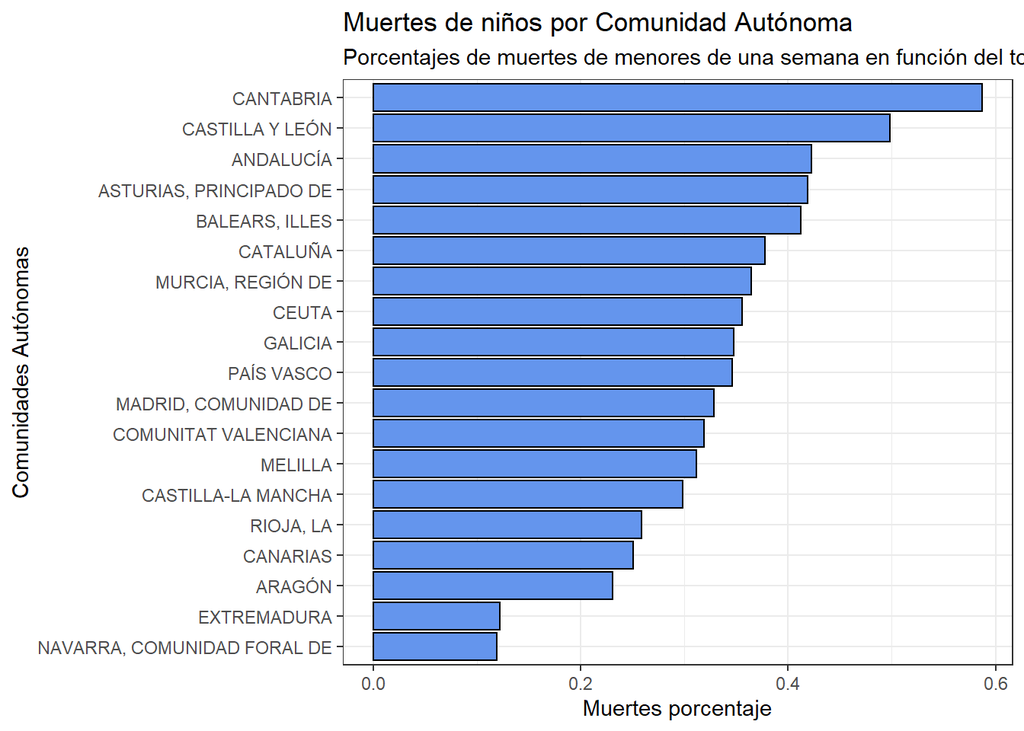

```r
ggplot(data = muertes_CCAA, aes(x = reorder(muertes_CCAA$`Comunidades y Ciudades Autónomas`,muertes_CCAA$muertes_comunidad_porcentaje), y = muertes_CCAA$muertes_comunidad_porcentaje))+
  geom_bar(stat = "identity",fill="cornflowerblue",colour="black")+
  theme(axis.text.x = element_text(angle = 90, vjust = 0.5, hjust=1))+
  coord_flip()+
  theme_bw()+
  labs(x="Comunidades Autónomas",y="Muertes porcentaje",title ="Muertes de niños por Comunidad Autónoma",subtitle = "Porcentajes de muertes de menores de una semana en función del total de nacimientos de cada Comunidad Autónoma")
```

Como podemos observar el mayor porcentaje de muertes se encuentra en la comunidad autónoma de Cantabria, seguida de Castilla y León y Andalucía. Recordemos que estos porcentajes se han obtenido a partir del total de nacimientos y muertes por cada comunidad.

A continuación vamos a mostrar el ejercicio de mujeres de nivel alto realizado por Comunidad Autónoma.

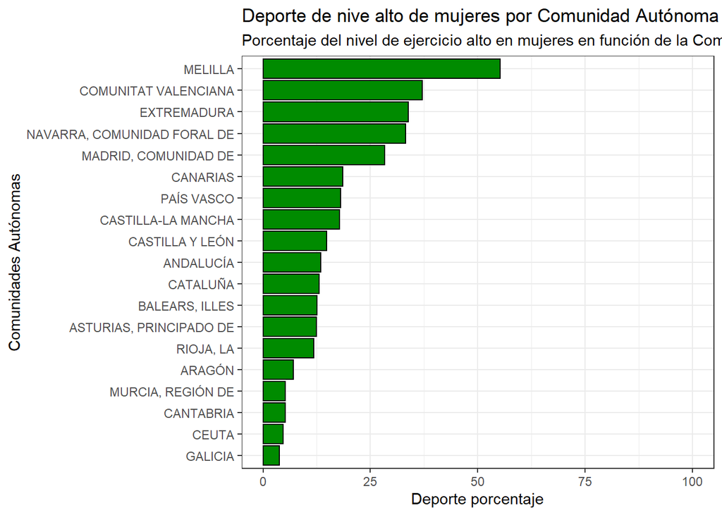

```r
grafico_alto<-ggplot(data = ejercicio_mujeres_comunidad, aes(x = reorder(`Comunidades y Ciudades Autónomas`,nivel_alto), y = nivel_alto))+
  geom_bar(stat = "identity",fill="green4",colour="black")+
  theme(axis.text.x = element_text(angle = 90, vjust = 0.5, hjust=1))+
  coord_flip()+
  expand_limits(y=c(0,100))+
  theme_bw()+
  labs(x="Comunidades Autónomas",y="Deporte porcentaje",title ="Deporte de nive alto de mujeres por Comunidad Autónoma",subtitle = "Porcentaje del nivel de ejercicio alto en mujeres en función de la Comunidad Autónoma")

grafico_alto
```

Vemos que Melilla es la comunidad autónoma donde las mujeres hacer un mayor ejercicio de nivel alto, superando el 50% sobre el total de mujeres que realizan deporte. En segundo lugar encontramos Comunidad Valenciana, y Extremadura en el tercero. Galicia por el contrario es la comunidad autónoma donde menos ejercicio de alto nivel se realiza entre las mujeres españolas.

Seguimos con la observación de el deporte, pero esta vez con un nivel moderado de ejercicio.

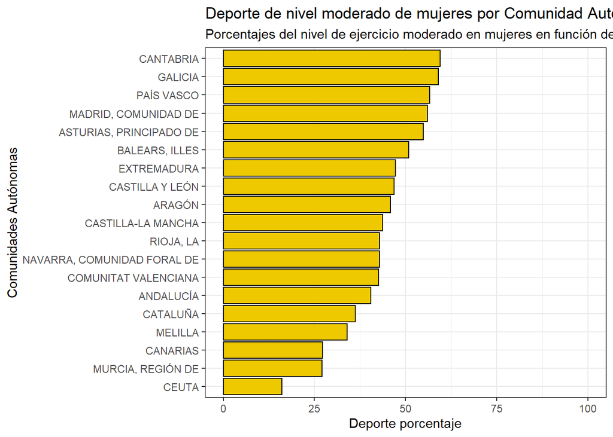

```r
grafico_moderado<-ggplot(data = ejercicio_mujeres_comunidad, aes(x = reorder(`Comunidades y Ciudades Autónomas`,nivel_moderado), y = nivel_moderado))+
  geom_bar(stat = "identity",fill="gold2",colour="black")+
  theme(axis.text.x = element_text(angle = 90, vjust = 0.5, hjust=1))+
  coord_flip()+
  expand_limits(y=c(0,100))+
  theme_bw()+
  labs(x="Comunidades Autónomas",y="Deporte porcentaje",title ="Deporte de nivel moderado de mujeres por Comunidad Autónoma",subtitle = "Porcentajes del nivel de ejercicio moderado en mujeres en función de la Comunidad Autónoma")

grafico_moderado
```

En este gráfico la mayoría de las CCAA mantienen unos niveles relativamente parecidos, manteniéndose en el top del ejercicio moderado Cantabria y empezando por la pate inferior la Comunidad Autónoma de Ceuta.

En el último nivel de deporte, es decir el deporte de nivel bajo, obtendríamos lo siguiente:

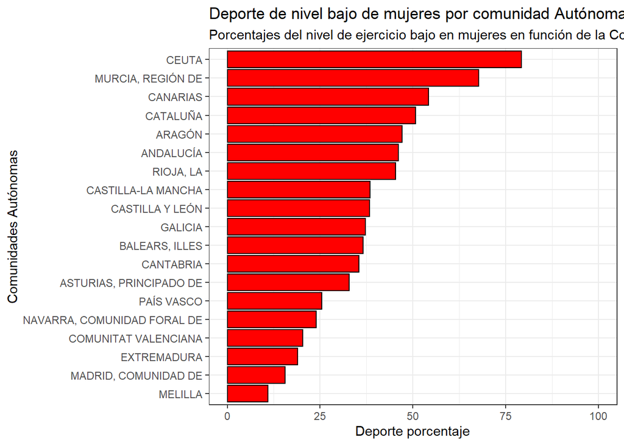

```r
grafico_bajo<-ggplot(data = ejercicio_mujeres_comunidad, aes(x = reorder(`Comunidades y Ciudades Autónomas`,nivel_bajo), y = nivel_bajo))+
  geom_bar(stat = "identity",fill="red",colour="black")+
  theme(axis.text.x = element_text(angle = 90, vjust = 0.5, hjust=1))+
  coord_flip()+
  expand_limits(y=c(0,100))+
  theme_bw()+
  labs(x="Comunidades Autónomas",y="Deporte porcentaje",title ="Deporte de nivel bajo de mujeres por comunidad Autónoma",subtitle = "Porcentajes del nivel de ejercicio bajo en mujeres en función de la Comunidad Autónoma")

grafico_bajo
```

Ceuta se sitúa como la Comudidad Autónoma donde mayor número de mujeres practíca un nivel bajo de ejercicio según datos recogidos por el ministerio; le siguen la Comunidad de Murcia y Canarias. Si observamos la comunidad que menos mujeres realizan ejercicio de nivel bajo, encontramos a Melilla, la cual, como hemos comentado anteriormente es la comunidad donde más se practica el ejercicio de alto nivel entre la población femenina que la compone, lo cual justifica los datos presentados por esta tabla de ejercicio bajo, al situarse como la última dentro de todas las CCAA.

```r
library("hrbrthemes")
library("patchwork")
```

```r
grafico_deporte <- grafico_alto+grafico_moderado+grafico_bajo
```

Para finalizar presentamos el Gráfico de relación de nuestro estudio.Este gráfico relaciona la porcentaje de ejrecicio realizado por la mujeres sobre 100 ,con el porcentaje de muertes de niños sobre 1. Estos datos como hemos comentado anteriormente han sido obtenidos de un `left_join` con CCAA como unión.

```r
long_union_tablas<-pivot_longer(data = union_tablas, names_to = "Variable", values_to = "Valores", cols = c(nivel_alto:nivel_bajo))

knitr::kable(
  head(long_union_tablas[,]),
  caption = 'A table of the first 10 rows of the mtcars data.'
)
```

| Comunidades y Ciudades Autónomas | suma_total | nacimientos | muertes_comunidad_porcentaje | Variable | Valores |
| --- | --- | --- | --- | --- | --- |
| ANDALUCÍA | 277 | 65522 | 0.4227588 | nivel_alto | 13.46 |
| ANDALUCÍA | 277 | 65522 | 0.4227588 | nivel_moderado | 40.45 |
| ANDALUCÍA | 277 | 65522 | 0.4227588 | nivel_bajo | 46.09 |
| ARAGÓN | 21 | 9095 | 0.2308961 | nivel_alto | 7.11 |
| ARAGÓN | 21 | 9095 | 0.2308961 | nivel_moderado | 45.79 |
| ARAGÓN | 21 | 9095 | 0.2308961 | nivel_bajo | 47.11 |

Con ello ya sería posible la representación de la gráfica de relación:

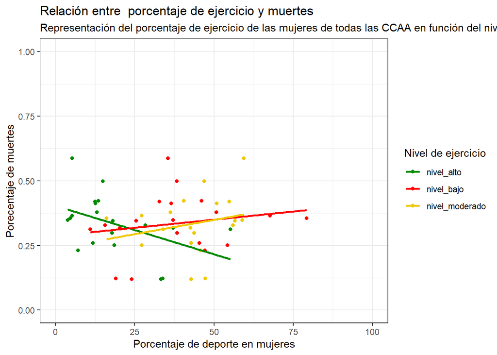

```r
ggplot(data=long_union_tablas,aes(x=Valores,y =muertes_comunidad_porcentaje,colour=Variable))+
  geom_point()+
  #geom_smooth()
  expand_limits(x=c(0,100),y=c(0,1))+
  geom_smooth(method = "nls", formula = y ~ a * x + b, se = F,
              method.args = list(start = list(a = 0.1, b = 0.1)))+
  scale_color_manual(values=c("green4","red","gold2"))+
  theme_bw()+
  labs(x="Porcentaje de deporte en mujeres",y="Porecentaje de muertes",title ="Relación entre  porcentaje de ejercicio y muertes",subtitle = "Representación del porcentaje de ejercicio de las mujeres de todas las CCAA en función del nivel, y su relación con la muerte de niños menores a una semana",colour= "Nivel de ejercicio")
```

## Referencias

**Datos muerte niños:**

Instituto Nacional de Estadística, 2021,

Datos sobre la cantidad de muertes de niños menores de una semana por comunidad autónoma,

(https://datos.gob.es/es/catalogo/ea0010587-defunciones-de-menores-de-una-semana-por-causas-lista-perinatal-reducida-sexo-y-comunidad-y-ciudad-autonoma-de-residencia-ecm-identificador-api-t15-p417-a2020-l0-02022-px)

**Datos sobre el deporte:**

Ministerio de Sanidad, 2017,

Recopilación de datos sobre el deporte en españa,

(https://www.sanidad.gob.es/estadEstudios/estadisticas/encuestaNacional/encuestaNac2017/encuestaResDetall2017.htm)

**Datos de natalidad:**

Natalidad de las comunidades autónomas,

Datosmacro.com, 2021,

(https://datosmacro.expansion.com/demografia/natalidad/espana-comunidades-autonomas)